# Taller 3

Alejandro Pinto

2024-11-01

## DATA Blocks

Para iniciar con el modelo de regresión generalizado, se inicia con la data *blocks* de la librería:

```r
library(GLMsData)
data(blocks)
head(blocks)
```

```
##   Child Number  Time Trial Shape  Age
## 1     A     11  30.0     1  Cube 4.67
## 2     B      9  19.0     1  Cube 5.00
## 3     C      8  18.6     1  Cube 4.42
## 4     D      9  23.0     1  Cube 4.33
## 5     E     10  29.0     1  Cube 4.33
## 6     F     13 178.0     1  Cube 4.83
```

Si revisamos las columnas y sus datos tenemos que:

```r
table(blocks$Shape)
```

```
##
##     Cube Cylinder
##       50       50
```

Observamos que la data tiene 6 variables:

Child: Identificador del niño, de A a Y. Number: Número de bloques que el niño logró apilar con éxito; un vector numérico. Time: Tiempo en segundos que los niños tardaron en apilar sus bloques; un vector numérico. Trial: Número de prueba en la que se recopilaron los datos; un factor con niveles 1 y 2. Shape: Forma de los bloques apilados; un factor con niveles Cubo y Cilindro. Age: Edad del niño en años completos; un vector numérico.

Para poder realizar el modelo lineal generalizado, necesitamos cambiar las variables categóricas a variables dummies:

```r
blocks$Shape = ifelse(blocks$Shape == "Cube",1,0)
head(blocks)
```

```
##   Child Number  Time Trial Shape  Age
## 1     A     11  30.0     1     1 4.67
## 2     B      9  19.0     1     1 5.00
## 3     C      8  18.6     1     1 4.42
## 4     D      9  23.0     1     1 4.33
## 5     E     10  29.0     1     1 4.33
## 6     F     13 178.0     1     1 4.83
```

En este caso, como la variable de interes es el tiempo de duran los niños en construir una torre, se realiza una prueba para determinar si se usa el modelo lineal generalizado gamma o inversa gausiana:

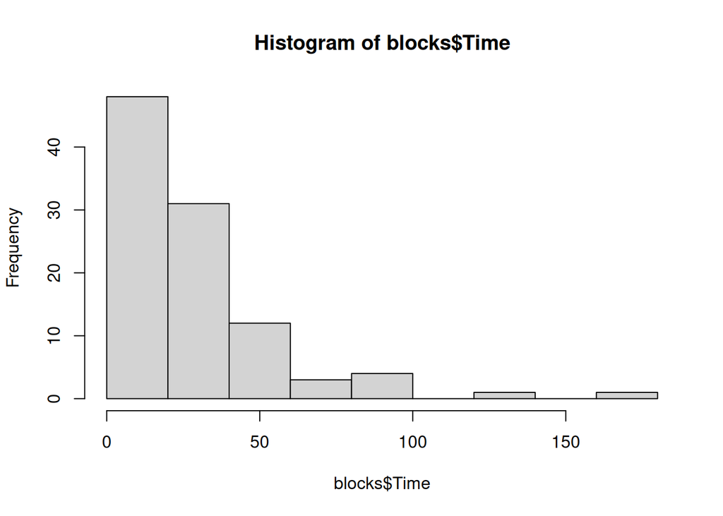

```r
hist(blocks$Time)
```

```r
modelblockg=glm(Time ~ Number + Trial + Shape + Age, data = blocks,family=Gamma(link="log"))
modelblockig=glm(Time ~ Number + Trial + Shape + Age, data = blocks,family=inverse.gaussian(link="log"))
log(logLik(modelblockig)/logLik(modelblockg))
```

```
## 'log Lik.' -0.01018081 (df=6)
```

Si el logaritmo del cociente de las versomilitudes del modelo son mayores a cero. Use un modelo inversa Gaussiana. En caso que este valor sea menor a cero un modelo gamma.

En este caso se observa que el valor es negativo, luego se hace un modelo gamma.

**A.** Seleccion del mejor subconjunto de variables predictoras:

Para esto recurrimos a la prueba de Akaike (AIC):

```r
step(modelblockg)
```

```
## Start:  AIC=797.99
## Time ~ Number + Trial + Shape + Age
##
##          Df Deviance    AIC
## - Trial   1   27.581 796.01
## - Shape   1   28.166 797.39
## <none>        27.574 797.99
## - Age     1   32.579 807.77
## - Number  1   44.888 836.74
##
## Step:  AIC=796.02
## Time ~ Number + Shape + Age
##
##          Df Deviance    AIC
## - Shape   1   28.175 795.43
## <none>        27.581 796.02
## - Age     1   32.582 805.90
## - Number  1   44.905 835.17
##
## Step:  AIC=796.25
## Time ~ Number + Age
```

```
##
## Call:  glm(formula = Time ~ Number + Age, family = Gamma(link = "log"),
##     data = blocks)
##
## Coefficients:
## (Intercept)       Number          Age
##      2.9451       0.2219      -0.2944
##
## Degrees of Freedom: 99 Total (i.e. Null);  97 Residual
## Null Deviance:       51.05
## Residual Deviance: 28.18     AIC: 796.2
```

Como se puede observar, las variables *Age* y *Number* explican bien el el tiempo de construccion de una torre, con un valor *AIC* de **796.25**.

Se eliminaron los predictores Trial y Shape, asi que se usarà este modelo:

```r
bestmodelblockg =glm(formula = Time ~ Number + Age, family = Gamma(link = "log"),
                     data = blocks)
```

para evaluar la calidad del ajuste al modelo

```r
library(DescTools)
PseudoR2(bestmodelblockg, "Nagelkerke")
```

```
## Nagelkerke
##  0.4685197
```

Existe una buena explicacion del tiempo empleado de los niños para construir torres con bloques cùbicos y cilindricos, por el modelo de regresion gamma. Ahora del summary:

```r
summary(bestmodelblockg)
```

```
##
## Call:
## glm(formula = Time ~ Number + Age, family = Gamma(link = "log"),
##     data = blocks)
##
## Coefficients:
##             Estimate Std. Error t value Pr(>|t|)
## (Intercept)  2.94508    0.37460   7.862 5.26e-12 ***
## Number       0.22193    0.03111   7.134 1.76e-10 ***
## Age         -0.29443    0.09315  -3.161   0.0021 **
## ---
## Signif. codes:  0 '***' 0.001 '**' 0.01 '*' 0.05 '.' 0.1 ' ' 1
##
## (Dispersion parameter for Gamma family taken to be 0.4303746)
##
##     Null deviance: 51.050  on 99  degrees of freedom
## Residual deviance: 28.175  on 97  degrees of freedom
## AIC: 796.25
##
## Number of Fisher Scoring iterations: 6
```

Podemos realizar la prueba Deviance:

```r
1-pchisq(51.050-28.175,2)
```

```
## [1] 1.078343e-05
```

Observandoo los coeficientes estimados: son menor a 0.05, rechace ho, existe evidencia estadistica de que el numero de bloques la edad del niño influye en el tiempo en el que deben cosntruir una torre.

```r
coef(bestmodelblockg)
```

```
## (Intercept)      Number         Age
##   2.9450795   0.2219259  -0.2944274
```

Para la variable Number:

```r
exp(0.2219259)
```

```
## [1] 1.248479
```

Por cada bloque adicional, el tiempo que tarda el niño en construir la torre aumenta 1.24 segundos, en promedio. Para la variable Age:

```r
1/exp(-0.2944274)
```

```
## [1] 1.342358
```

```r
testblock = data.frame(Trial = 2, Number=10, Shape=1, Age=5)
predict(bestmodelblockg,testblock, type="response")
```

```
##       1
## 40.1331
```

Un niño con 5 años se espera que tenga arpoximadamente 40.1331 segundos en construir una torre con bloques, independientemente si son cubicos o no.

**B.** Datos atipicos e influyentes:

En el caso del modelo lineal generalizado, podemos revisar los datos atipicos residuales de Deviance y Pearson y comparamos sus resultados. Si graficamos los residuos:

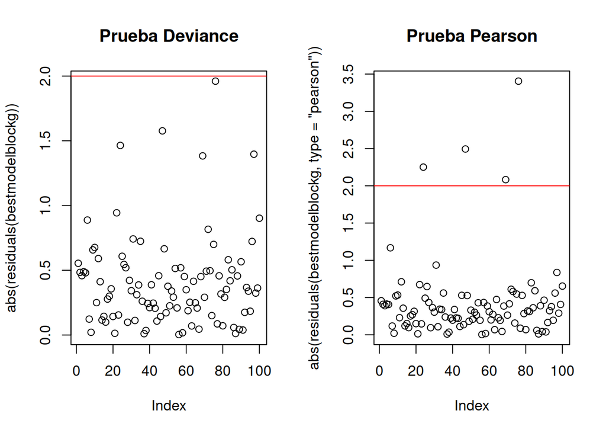

```r
par(mfrow=c(1,2))
plot(abs(residuals(bestmodelblockg)), main = "Prueba Deviance")
abline(h=2,col="red")
plot(abs(residuals(bestmodelblockg,type="pearson")), main = "Prueba Pearson")
abline(h=2,col="red")
```

No se observan datos atipicos en la primera prubea, pero se registran 4 datos atipicos en la segunda prueba.

```r
atipicos=data.frame(deviance=abs(residuals(bestmodelblockg)), pearson=abs(residuals(bestmodelblockg,type="pearson")))
atipicos[atipicos$deviance>2 & atipicos$pearson>2,]
```

```
## [1] deviance pearson
## <0 rows> (or 0-length row.names)
```

La tabla anerior nos muestra los datos mayores a *2* para la prueba Deviance y la prueba Pearson. Es decir, hay 0 datos que se consideran datos atìpicos.

Pasando a los datos influyentes, podemos revisar los StudResd, Hat-values y la distancia de Cook:

```r
library(car)
```

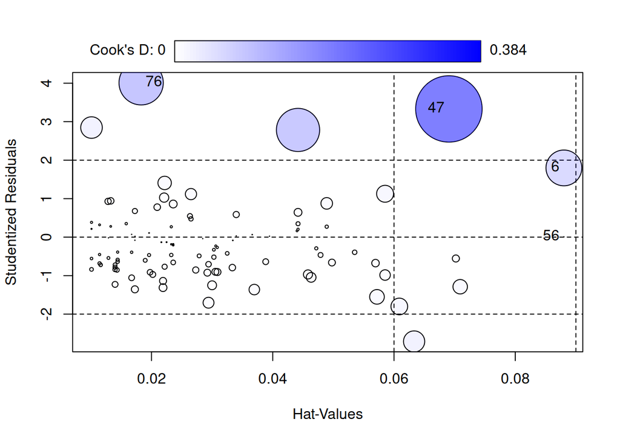

```
##        StudRes        Hat        CookD
## 6  1.798213385 0.08802096 1.118017e-01
## 47 3.330975397 0.06905116 3.839142e-01
## 56 0.006874005 0.08802096 1.038929e-06
## 76 4.008848835 0.01829075 1.704523e-01
```

```r
par(mfrow=c(1,1))
influencePlot(bestmodelblockg)
```

## DATA Leukwbc

Para iniciar con el modelo de regresión generalizado, se inicia con la data *Leeukwbc* de la librería:

```r
library(GLMsData)
data("leukwbc")
dim(leukwbc)
```

```
## [1] 33  3
```

```r
head(leukwbc)
```

```
##     WBC Time AG
## 1  2300   65  1
## 2   750  156  1
## 3  4300  100  1
## 4  2600  134  1
## 5  6000   16  1
## 6 10500  108  1
```

Si revisamos las columnas y sus datos tenemos que:

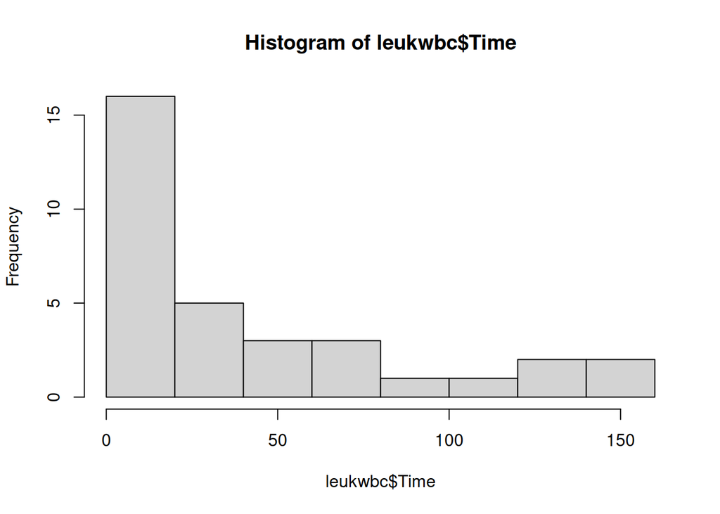

```r
hist(leukwbc$Time)
```

Observamos que la data con 33 observaciones sobre las siguientes 3 variables:

WBC: Conteo de glóbulos blancos; un vector numérico. Time: Tiempo hasta la muerte en semanas; un vector numérico. AG: Variable morfológica, el factor ag; un vector numérico donde 1 significa ag-positivo y 2 significa ag-negativo.

En este caso, como la variable de interes es el tiempo hasta la muerte y conteo de glóbulos blancos en dos grupos de pacientes con leucemia, se realiza una prueba para determinar si se usa el modelo lineal generalizado gamma o inversa gausiana:

```r
modeleukg=glm(Time ~ WBC + AG, data = leukwbc,family=Gamma(link="log"))
modeleukig=glm(Time ~ WBC + AG, data = leukwbc,family=inverse.gaussian(link="log"))
log(logLik(modeleukig)/logLik(modeleukg))
```

```
## 'log Lik.' 0.03151353 (df=4)
```

Si el logaritmo del cociente de las versomilitudes del modelo son mayores a cero. Use un modelo inversa Gaussiana. En caso que este valor sea menor a cero un modelo gamma.

**A.** Seleccion del mejor subconjunto de variables predictoras:

Para esto recurrimos a la prueba de Akaike (AIC):

```r
step(modeleukg)
```

```
## Start:  AIC=305.18
## Time ~ WBC + AG
##
##        Df Deviance    AIC
## - WBC   1   46.198 304.99
## <none>      44.292 305.18
## - AG    1   53.085 311.52
##
## Step:  AIC=304.85
## Time ~ AG
##
##        Df Deviance    AIC
## <none>      46.198 304.85
## - AG    1   58.138 314.67
```

```
##
## Call:  glm(formula = Time ~ AG, family = Gamma(link = "log"), data = leukwbc)
##
## Coefficients:
## (Intercept)           AG
##       5.382       -1.248
##
## Degrees of Freedom: 32 Total (i.e. Null);  31 Residual
## Null Deviance:       58.14
## Residual Deviance: 46.2  AIC: 304.9
```

Como se puede observar, la variable *AG* explica bien el el tiempo de muerte de pacientes con leucemia, con un valor *AIC* de **304.85**.

```r
bestmodeleukig =glm(formula = Time ~ AG, family = Gamma(link = "log"), data = leukwbc)
```

para evaluar la calidad del ajuste al modelo

```r
library(DescTools)
PseudoR2(bestmodeleukig, "Nagelkerke")
```

```
## Nagelkerke
##  0.2454965
```

```r
summary(bestmodeleukig)
```

```
##
## Call:
## glm(formula = Time ~ AG, family = Gamma(link = "log"), data = leukwbc)
##
## Coefficients:
##             Estimate Std. Error t value Pr(>|t|)
## (Intercept)   5.3825     0.5486   9.812 5.04e-11 ***
## AG           -1.2478     0.3502  -3.564  0.00121 **
## ---
## Signif. codes:  0 '***' 0.001 '**' 0.01 '*' 0.05 '.' 0.1 ' ' 1
##
## (Dispersion parameter for Gamma family taken to be 1.010594)
##
##     Null deviance: 58.138  on 32  degrees of freedom
## Residual deviance: 46.198  on 31  degrees of freedom
## AIC: 304.85
##
## Number of Fisher Scoring iterations: 6
```

Podemos realizar la prueba Deviance:

```r
1-pchisq(58.138-46.198,1)
```

```
## [1] 0.0005494148
```

Observandoo los coeficientes estimados:menor a0.05, rechace ho, existe evidencia estadistica de que la variable morfològica AG influye en el tiempo de muerte de pacientes con leucemia.

```r
coef(bestmodeleukig)
```

```
## (Intercept)          AG
##    5.382498   -1.247802
```

```r
1/exp(coef(bestmodeleukig))
```

```
## (Intercept)          AG
## 0.004596325 3.482680877
```

Por cada valor AG, el tiempo de muerte de un paciente con leucemia disminuye 3.48, en promedio.

B. Prediccion con WBG = 1000, AG = 1:

```r
testleuk = data.frame(WBC = 1000, AG=1)
predict(bestmodeleukig,testleuk, type="response")
```

```
##        1
## 62.47059
```

Un paciente con leucemia, Ag positivo y 1000 celulas blancas, se espera que el tiempo de muerte sea de 62.47 semanas.

**B.** Datos atipicos e influyentes:

En el caso del modelo lineal generalizado, podemos revisar los datos atipicos residuales de Deviance y Pearson y comparamos sus resultados. Si graficamos los residuos:

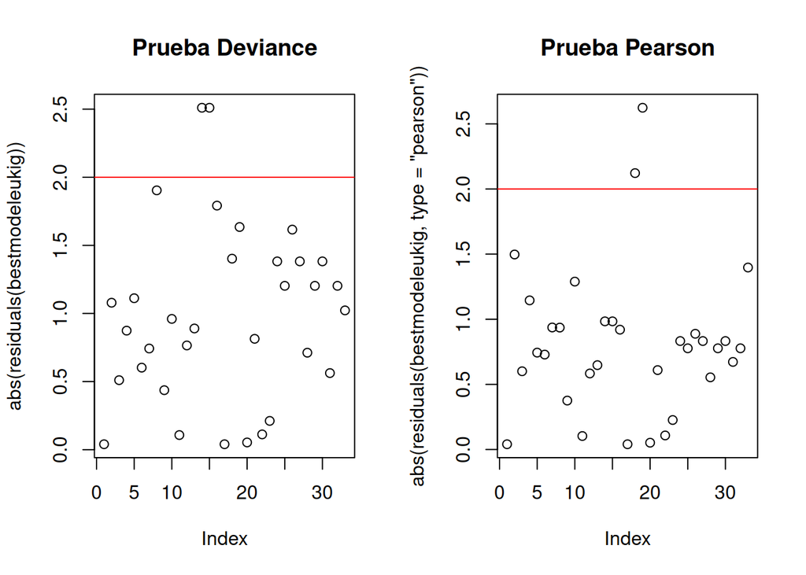

```r
par(mfrow=c(1,2))
plot(abs(residuals(bestmodeleukig)), main = "Prueba Deviance")
abline(h=2,col="red")
plot(abs(residuals(bestmodeleukig,type="pearson")), main = "Prueba Pearson")
abline(h=2,col="red")
```

Se observan dos datos atipicos

```r
residuos=data.frame(deviance=abs(residuals(bestmodeleukig)),
                    pearson=abs(residuals(bestmodeleukig,
                                          type="pearson")))
residuos[residuos$deviance>2& residuos$pearson>2,]
```

```
## [1] deviance pearson
## <0 rows> (or 0-length row.names)
```

La tabla anerior nos muestra los datos mayores a *2* para la prueba Deviance y la prueba Pearson. Es decir, hay o datos que se consideran datos atìpicos.

Pasando a los datos influyentes, podemos revisar los StudResd, Hat-values y la distancia de Cook:

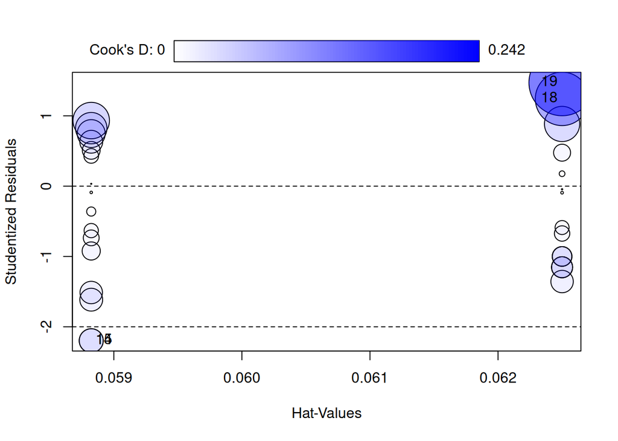

```
##      StudRes        Hat      CookD
## 14 -2.198060 0.05882353 0.03181161
## 15 -2.198060 0.05882353 0.03181161
## 18  1.241887 0.06250000 0.15841688
## 19  1.472112 0.06250000 0.24219034
```

```r
library(car)
par(mfrow=c(1,1))
influencePlot(bestmodeleukig)
```

Se observan 4 posibles datos influyentes: *14*, *15*, *18* y *19*. Si analizamos La distancia de Cook, ninguno pasa la prueba. Por ende, no se observan datos influyentes.

## DATA Affairs

Para iniciar con el modelo de regresión generalizado, se inicia con la data *Affairs* de la librería:

```r
library(AER)
data("Affairs")
dim(Affairs)
```

```
## [1] 601   9
```

```r
head(Affairs)
```

```
##    affairs gender age yearsmarried children religiousness education occupation
## 4        0   male  37        10.00       no             3        18          7
## 5        0 female  27         4.00       no             4        14          6
## 11       0 female  32        15.00      yes             1        12          1
## 16       0   male  57        15.00      yes             5        18          6
## 23       0   male  22         0.75       no             2        17          6
## 29       0 female  32         1.50       no             2        17          5
##    rating
## 4       4
## 5       4
## 11      4
## 16      5
## 23      3
## 29      5
```

Si revisamos las columnas y sus datos tenemos que:

```r
table(Affairs$children)
```

```
##
##  no yes
## 171 430
```

```r
Affairs$gender = ifelse(Affairs$gender=="male",1,0)
Affairs$children = ifelse(Affairs$children=="yes",1,0)
```

affairs: Frecuencia de participación en relaciones sexuales extramaritales en el último año (variable numérica): 0 = ninguna, 1 = una vez, 2 = dos veces, 3 = tres veces, 7 = de 4 a 10 veces, 12 = mensual, semanal o diario. gender: Género; variable categórica. age: Edad en años (variable numérica): 17.5 = menor de 20, 22 = 20–24, 27 = 25–29, 32 = 30–34, 37 = 35–39, 42 = 40–44, 47 = 45–49, 52 = 50–54, 57 = 55 o más. yearsmarried: Años de matrimonio (variable numérica): 0.125 = 3 meses o menos, 0.417 = 4–6 meses, 0.75 = de 6 meses a 1 año, 1.5 = de 1 a 2 años, 4 = de 3 a 5 años, 7 = de 6 a 8 años, 10 = de 9 a 11 años, 15 = 12 años o más. children: Indica si hay hijos en el matrimonio; variable categórica. religiousness: Nivel de religiosidad (variable numérica): 1 = anti-religioso, 2 = nada religioso, 3 = algo religioso, 4 = moderadamente religioso, 5 = muy religioso. education: Nivel educativo (variable numérica): 9 = escuela primaria, 12 = graduado de secundaria, 14 = algo de universidad, 16 = graduado de universidad, 17 = estudios de posgrado, 18 = maestría, 20 = doctorado, medicina u otro título avanzado. occupation: Ocupación según la clasificación de Hollingshead (con numeración inversa); variable numérica. rating: Autoevaluación de la felicidad en el matrimonio (variable numérica): 1 = muy infeliz, 2 = algo infeliz, 3 = promedio, 4 = más feliz que el promedio, 5 = muy feliz.

En este caso, como la variable de interes es la cantidad de infidelidades, se realiza una prueba de Cameron para determinar si sobredispersion o no:

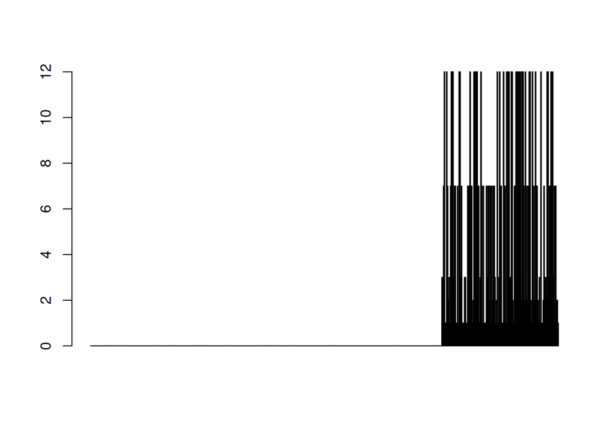

```r
modelaffair=glm(affairs~.,family=poisson,data=Affairs)

barplot(Affairs$affairs)
```

```r
dispersiontest(modelaffair,trafo=1)
```

```
##
##  Overdispersion test
##
## data:  modelaffair
## z = 5.2595, p-value = 7.224e-08
## alternative hypothesis: true alpha is greater than 0
## sample estimates:
##    alpha
## 5.873703
```

menor a 0.05. REchace Ho. Existe evidencia estadistica de que hay sobredispersion. En este caso se realiza el modelo con la distribuciòn binomial negativa

```r
library(MASS)
modelaffairnb=glm.nb(affairs~.,data=Affairs)
summary(modelaffairnb)
```

```
##
## Call:
## glm.nb(formula = affairs ~ ., data = Affairs, init.theta = 0.1427050721,
##     link = log)
##
## Coefficients:
##                 Estimate Std. Error z value Pr(>|z|)
## (Intercept)    2.3381919  1.0425812   2.243 0.024916 *
## gender        -0.0186320  0.2776900  -0.067 0.946505
## age            0.0002843  0.0207056   0.014 0.989046
## yearsmarried   0.0803867  0.0380018   2.115 0.034401 *
## children       0.1161738  0.3288787   0.353 0.723907
## religiousness -0.4257717  0.1042682  -4.083 4.44e-05 ***
## education     -0.0260332  0.0591538  -0.440 0.659869
## occupation     0.0807710  0.0828678   0.975 0.329711
## rating        -0.4152284  0.1087853  -3.817 0.000135 ***
## ---
## Signif. codes:  0 '***' 0.001 '**' 0.01 '*' 0.05 '.' 0.1 ' ' 1
##
## (Dispersion parameter for Negative Binomial(0.1427) family taken to be 1)
##
##     Null deviance: 391.17  on 600  degrees of freedom
## Residual deviance: 339.61  on 592  degrees of freedom
## AIC: 1476.2
##
## Number of Fisher Scoring iterations: 1
##
##
##               Theta:  0.1427
##           Std. Err.:  0.0160
##
##  2 x log-likelihood:  -1456.2010
```

**A.** Seleccion del mejor subconjunto de variables predictoras:

Para esto recurrimos a la prueba de Akaike (AIC):

```r
step(modelaffairnb)
```

```
## Start:  AIC=1474.2
## affairs ~ gender + age + yearsmarried + children + religiousness +
##     education + occupation + rating
##
##                 Df Deviance    AIC
## - age            1   339.61 1472.2
## - gender         1   339.62 1472.2
## - children       1   339.75 1472.3
## - education      1   339.79 1472.4
## - occupation     1   340.52 1473.1
## <none>               339.61 1474.2
## - yearsmarried   1   343.91 1476.5
## - rating         1   353.45 1486.0
## - religiousness  1   354.75 1487.3
##
## Step:  AIC=1472.2
## affairs ~ gender + yearsmarried + children + religiousness +
##     education + occupation + rating
##
##                 Df Deviance    AIC
## - gender         1   339.63 1470.2
## - children       1   339.76 1470.3
## - education      1   339.80 1470.4
## - occupation     1   340.53 1471.1
## <none>               339.62 1472.2
## - yearsmarried   1   348.65 1479.2
## - rating         1   353.85 1484.4
## - religiousness  1   355.15 1485.7
##
## Step:  AIC=1470.21
## affairs ~ yearsmarried + children + religiousness + education +
##     occupation + rating
##
##                 Df Deviance    AIC
## - children       1   339.75 1468.3
## - education      1   339.81 1468.4
## - occupation     1   340.56 1469.2
## <none>               339.61 1470.2
## - yearsmarried   1   348.70 1477.3
## - rating         1   353.89 1482.5
```

[output cut: 17 more lines]

```
##                 Df Deviance    AIC
## - occupation     1   340.28 1465.2
## <none>               339.57 1466.5
## - yearsmarried   1   351.02 1476.0
## - religiousness  1   355.42 1480.4
## - rating         1   357.10 1482.0
##
## Step:  AIC=1465.22
## affairs ~ yearsmarried + religiousness + rating
##
##                 Df Deviance    AIC
## <none>               339.33 1465.2
## - yearsmarried   1   352.35 1476.2
## - religiousness  1   356.10 1480.0
## - rating         1   356.21 1480.1
```

```
##
## Call:  glm.nb(formula = affairs ~ yearsmarried + religiousness + rating,
##     data = Affairs, init.theta = 0.141882111, link = log)
##
## Coefficients:
##   (Intercept)   yearsmarried  religiousness         rating
##       2.36869        0.08531       -0.43515       -0.42355
##
## Degrees of Freedom: 600 Total (i.e. Null);  597 Residual
## Null Deviance:       389.6
## Residual Deviance: 339.3     AIC: 1467
```

Se eliminò el predictor age, gender, children, education, occupation, asi que se usarà este modelo:

```r
  bestmodelaffairnb=glm.nb(formula = affairs ~ yearsmarried + religiousness + rating,
                           data = Affairs, init.theta = 0.141882111, link = log)
```

para evaluar la calidad del ajuste al modelo

```r
library(DescTools)
PseudoR2(bestmodelaffairnb, "Nagelkerke")
```

```
## Nagelkerke
## 0.07881018
```

Existe una mala explicacion de la cantidad de infidelidades, por el modelo de regresion binomial negativa. . Ahora del summary:

```r
summary(bestmodelaffairnb)
```

```
##
## Call:
## glm.nb(formula = affairs ~ yearsmarried + religiousness + rating,
##     data = Affairs, init.theta = 0.1418818828, link = log)
##
## Coefficients:
##               Estimate Std. Error z value Pr(>|z|)
## (Intercept)    2.36871    0.55987   4.231 2.33e-05 ***
## yearsmarried   0.08531    0.02242   3.806 0.000141 ***
## religiousness -0.43516    0.10408  -4.181 2.90e-05 ***
## rating        -0.42355    0.10748  -3.941 8.13e-05 ***
## ---
## Signif. codes:  0 '***' 0.001 '**' 0.01 '*' 0.05 '.' 0.1 ' ' 1
##
## (Dispersion parameter for Negative Binomial(0.1419) family taken to be 1)
##
##     Null deviance: 389.62  on 600  degrees of freedom
## Residual deviance: 339.33  on 597  degrees of freedom
## AIC: 1467.2
##
## Number of Fisher Scoring iterations: 1
##
##
##               Theta:  0.1419
##           Std. Err.:  0.0158
##
##  2 x log-likelihood:  -1457.2180
```

Podemos realizar la prueba Deviance:

```r
1-pchisq(389.62-339.33,3)
```

```
## [1] 6.930079e-11
```

menor a 0.05, rechace ho, existe evidencia estadistica de que el modelo de regresion binomial inversa se ajusta a los datos.

Observandoo los coeficientes estimados:menor a0.05, rechace ho, existe evidencia estadistica de que las variables yearsmarried, religiousness y rating influyen en el numero de infidelidades.

Interpretacion de los coeficientes estimados del modelo

```r
coef(bestmodelaffairnb)
```

```
##   (Intercept)  yearsmarried religiousness        rating
##    2.36870641    0.08530847   -0.43516099   -0.42355410
```

```r
exp(0.08530847)
```

```
## [1] 1.089053
```

Si el numero de años casados aumenta, el numero de infidelidades aumenta en promedio 1.089.

```r
1/exp(-0.43516099)
```

```
## [1] 1.545212
```

```r
1/exp(-0.42355410)
```

```
## [1] 1.52738
```

Si el matrimonio va mal, el numero de infidelidades aumenta en promedio 1.527.

**B.** Datos atipicos e influyentes:

En el caso del modelo lineal generalizado, podemos revisar los datos atipicos residuales de Deviance y Pearson y comparamos sus resultados. Si graficamos los residuos:

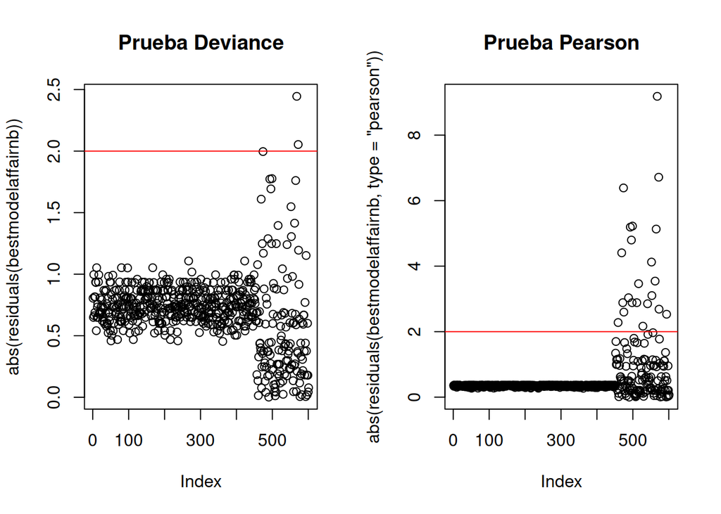

```r
par(mfrow=c(1,2))
plot(abs(residuals(bestmodelaffairnb)), main = "Prueba Deviance")
abline(h=2,col="red")
plot(abs(residuals(bestmodelaffairnb,type="pearson")), main = "Prueba Pearson")
abline(h=2,col="red")
```

Se observa una amplia data de datos atipìcos

```r
residuos=data.frame(deviance=abs(residuals(bestmodelaffairnb)),
                    pearson=abs(residuals(bestmodelaffairnb,
                                          type="pearson")))
residuos[residuos$deviance>2& residuos$pearson>2,]
```

```
##      deviance  pearson
## 1622 2.445133 9.185573
## 1674 2.053562 6.715776
```

La tabla anerior nos muestra los datos mayores a *2* para la prueba Deviance y la prueba Pearson. Es decir, hay 2 datos que se consideran datos atìpicos.

Pasando a los datos influyentes, podemos revisar los StudResd, Hat-values y la distancia de Cook:

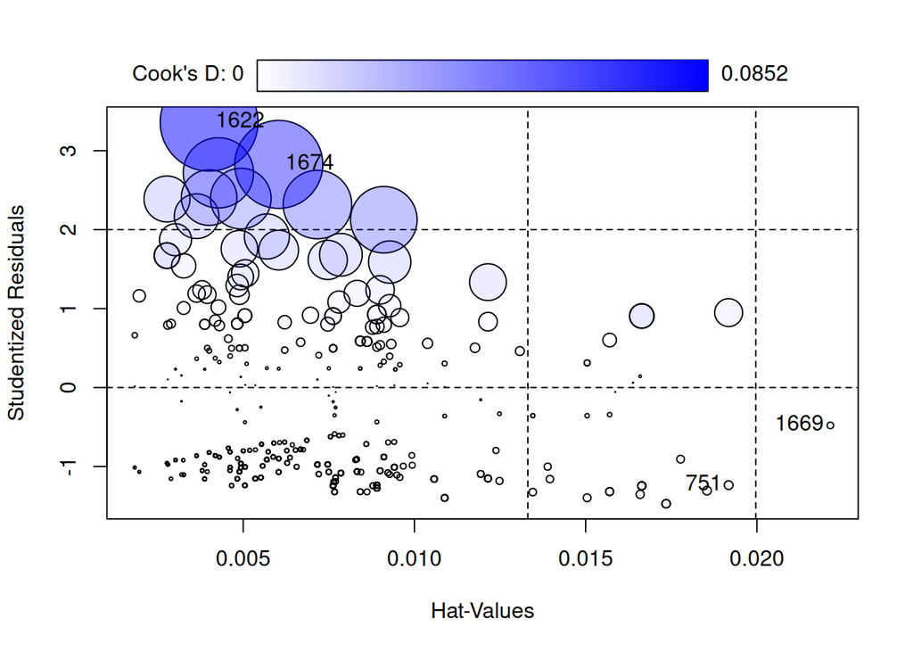

```
##         StudRes         Hat        CookD
## 751  -1.2364689 0.019173523 0.0006734711
## 1622  3.3610697 0.004006078 0.0851840990
## 1669 -0.4795884 0.022144568 0.0003780502
## 1674  2.8263272 0.006039737 0.0689306672
```

```r
library(car)
par(mfrow=c(1,1))
influencePlot(bestmodelaffairnb)
```

Se observan 4 posibles datos influyentes: *751*, *1622*, *1669* y *1674*. Si analizamos La distancia de Cook, ninguno pasa la prueba. Por ende, no se observan datos influyentes.

**C.** Prediccion con gender = 1, Age = 37, Yearsmarried = 8, Children = 0, religiousness = 3, education = 188, rating = 5 y occupation = 8:

```r
testaffair = data.frame(yearsmarried = 8, religiousness=3, rating = 5)
predict(bestmodelaffairnb,testaffair, type="response")
```

```
##         1
## 0.6892996
```

El promedio esperado de infidelidad de un hombre casado 8 años, poco religioso y muy feliz en el matrimnio, es de 0.68.